# WINN Comparison Notebook

This notebook compares **WINN** against commonly used metabolomics correction methods, including **QC‑RLSC**, **QC‑RFSC**, **QC‑LOESS**, **SERRF**, and **ComBat**. It also includes practical baselines (raw and PQN-only) and a widely used batch‑correction alternative (`limma::removeBatchEffect`).

All metrics are computed on **simulated LC‑MS data** with known drift, batch effects, and sample‑wise dilution. Biological groups are randomized *within each batch* and QC samples appear every 8th measurement.

## 1. Dependencies

This notebook uses a few optional packages. If some are missing, those methods will be skipped.

```r
req <- function(pkg) {
  if (!requireNamespace(pkg, quietly = TRUE)) {
    message("Package not installed: ", pkg)
    return(FALSE)
  }
  TRUE
}

has_winn <- req("winn")
has_sva <- req("sva")
has_limma <- req("limma")
has_statTarget <- req("statTarget")
has_serrf <- req("SERRF")
```

```
#> Package not installed: SERRF
```

```r
serrf_pkg <- NULL
if (!has_serrf) {
  has_serrf <- req("serrf")
  if (has_serrf) serrf_pkg <- "serrf"
} else {
  serrf_pkg <- "SERRF"
}
```

```
#> Package not installed: serrf
```

```r
has_qcrlscR <- req("qcrlscR")
```

## 2. Simulate LC‑MS data with drift + batch effects

```r
set.seed(42)

n_met <- 50
n_samples <- 201
n_batches <- 4
samples_per_batch <- floor(n_samples / n_batches)

batch <- rep(seq_len(n_batches), each = samples_per_batch, length.out = n_samples)
run_order <- seq_len(n_samples)

qc_idx <- unique(c(seq(1, n_samples, by = 8), n_samples))
non_qc_idx <- setdiff(seq_len(n_samples), qc_idx)

# Randomize biological groups along measurement order (QC excluded),
# with equal A/B counts within each batch
group <- rep(NA_character_, n_samples)
group[qc_idx] <- "QC"
for (b in seq_len(n_batches)) {
  idx_b <- which(batch == b)
  non_qc_b <- intersect(idx_b, non_qc_idx)
  n_b <- length(non_qc_b)
  labels <- rep(c("A", "B"), length.out = n_b)
  group[non_qc_b] <- sample(labels)
}

# True log-scale signal (no drift; centered around metabolite-specific mean)
base_mean <- rnorm(n_met, mean = 8, sd = 0.5)
baseline_log <- base_mean + matrix(rnorm(n_met * n_samples, mean = 0, sd = 0.1), nrow = n_met)

# Binary group effect (10–20% of metabolites)
effect_prop <- runif(1, 0.10, 0.20)
effect_count <- max(1, round(n_met * effect_prop))
effect_metabolites <- sort(sample(seq_len(n_met), effect_count))
true_effect <- rep(0, n_met)
true_effect[effect_metabolites] <- rnorm(effect_count, mean = 0.8, sd = 0.1)

true_log <- baseline_log
true_log[effect_metabolites, group == "B"] <- true_log[effect_metabolites, group == "B"] +
  true_effect[effect_metabolites]

# Continuous covariate (5–10% of metabolites), independent of run order
cont_var <- runif(n_samples, min = 0, max = 1)
cont_var[qc_idx] <- 0
cont_prop <- runif(1, 0.05, 0.10)
cont_count <- max(1, round(n_met * cont_prop))
cont_metabolites <- setdiff(seq_len(n_met), effect_metabolites)
cont_metabolites <- sort(sample(cont_metabolites, cont_count))
cont_effect <- rep(0, n_met)
# Weaker effect size (0.6-0.9 instead of 1.2) so drift/batch noise matters more
cont_effect[cont_metabolites] <- rnorm(cont_count, mean = 0.75, sd = 0.08)
true_log[cont_metabolites, ] <- true_log[cont_metabolites, ] +
  cont_effect[cont_metabolites] %*% t(cont_var)

# QC samples: pooled reference
pooled_log <- rowMeans(true_log[, group != "QC", drop = FALSE])
true_log[, qc_idx] <- pooled_log

# Sample-wise dilution (multiplicative)
dilution_factor <- exp(rnorm(n_samples, mean = 0, sd = 0.08))

# Drift per batch (warm-up -> plateau -> decline with non-linear curvature)
smoothstep <- function(x) {
  x <- pmin(pmax(x, 0), 1)
  x * x * (3 - 2 * x)
}

make_batch_drift <- function(n, shape = c("linearish", "nonlinear")) {
  shape <- match.arg(shape)
  n1 <- floor(n * 0.30)
  n2 <- floor(n * 0.45)
  n3 <- n - n1 - n2

  up <- smoothstep(seq(0, 1, length.out = n1))
  flat <- rep(1, n2)
  down <- 1 - smoothstep(seq(0, 1, length.out = n3))
  base <- c(up, flat, down)

  curve_strength <- ifelse(shape == "nonlinear", 0.15, 0.06)
  curve <- curve_strength * (seq_len(n) / n - 0.5)^2
  rw <- cumsum(rnorm(n, mean = 0, sd = ifelse(shape == "nonlinear", 0.012, 0.008)))
  base <- base + curve + rw

  base <- base - min(base)
  base <- base / max(base)
  base
}

drift_log <- matrix(0, nrow = n_met, ncol = n_samples)
# 20-25% with strong drift, 20-25% with minimal drift, rest moderate
drift_tier <- runif(n_met)
strong_mask <- drift_tier < 0.25
low_mask <- drift_tier >= 0.75
drift_severity <- numeric(n_met)
drift_severity[strong_mask] <- runif(sum(strong_mask), 0.20, 0.38)
drift_severity[low_mask] <- runif(sum(low_mask), 0.00, 0.03)
drift_severity[!(strong_mask | low_mask)] <- runif(sum(!(strong_mask | low_mask)), 0.10, 0.18)
amp <- rnorm(n_met, mean = drift_severity, sd = pmax(drift_severity * 0.2, 0.01))
for (b in seq_len(n_batches)) {
  idx <- which(batch == b)
  shape <- ifelse(b %% 2 == 0, "nonlinear", "linearish")
  trend_b <- make_batch_drift(length(idx), shape = shape)
  drift_log[, idx] <- amp %*% t(trend_b)
}

# Batch effects (per-metabolite, variable severity)
batch_severity <- numeric(n_met)
batch_severity[strong_mask] <- runif(sum(strong_mask), 0.40, 0.80)
batch_severity[low_mask] <- runif(sum(low_mask), 0.00, 0.04)
batch_severity[!(strong_mask | low_mask)] <- runif(sum(!(strong_mask | low_mask)), 0.06, 0.20)
batch_shift_mat <- sapply(seq_len(n_batches), function(b) rnorm(n_met, mean = 0, sd = batch_severity))
batch_scale_mat <- sapply(seq_len(n_batches), function(b) exp(rnorm(n_met, mean = 0, sd = batch_severity / 2)))

batch_log <- matrix(0, nrow = n_met, ncol = n_samples)
for (b in seq_len(n_batches)) {
  idx <- which(batch == b)
  batch_log[, idx] <- batch_shift_mat[, b] + log(batch_scale_mat[, b])
}

# Homoscedastic noise (constant variance across intensities)
noise_log <- matrix(rnorm(n_met * n_samples, mean = 0, sd = 0.12), nrow = n_met)

# Observed data in intensity space
observed_log <- true_log +
  matrix(log(dilution_factor), nrow = n_met, ncol = n_samples, byrow = TRUE) +
  drift_log +
  batch_log +
  noise_log

true_intensity <- pmax(expm1(true_log), 0)
observed_intensity <- pmax(expm1(observed_log), 0)

# Add sample names (used by some methods)
colnames(observed_intensity) <- paste0("S", seq_len(n_samples))
colnames(true_intensity) <- colnames(observed_intensity)
```

## 3. Run correction methods

```r
if (!has_winn) stop("winn package is required for this notebook")

library(winn)

# WINN
winn_without_qcs <- winn(
  observed_intensity,
  batch = batch,
  run_order = run_order,
  median_adjustment = "shrink",
  remove_batch_effects = "anova",
  scale_by_batch = FALSE
)
```

```
#> Starting Winn correction...
```

```
#> Adjusting outliers using MAD...
```

```
#> Correcting drift using autocorrelation test (Ljung-Box) with FDR threshold: 0.05...
```

```
#> Correcting batch effects using ANOVA-based residualization with FDR threshold: 0.05...
```

```
#> Performing median adjustment using method: shrink
```

```
#> Winn correction completed.
```

```r
winn_qc_auto <- winn(
  observed_intensity,
  batch = batch,
  run_order = run_order,
  control_samples = qc_idx,
  parameters = "auto",
  median_adjustment = "shrink",
  remove_batch_effects = "anova",
  scale_by_batch = FALSE
)
```

```
#> Starting Winn correction...
```

```
#> Adjusting outliers using MAD...
```

```
#> Auto-detecting optimal parameters using control samples...
```

```
#> Parameter optimization progress: 9.7%
```

```
#> Parameter optimization progress: 19.4%
```

```
#> Parameter optimization progress: 29.2%
```

```
#> Parameter optimization progress: 38.9%
```

```
#> Parameter optimization progress: 48.6%
```

```
#> Parameter optimization progress: 58.3%
```

```
#> Parameter optimization progress: 68.1%
```

```
#> Parameter optimization progress: 77.8%
```

```
#> Parameter optimization progress: 87.5%
```

```
#> Parameter optimization progress: 97.2%
```

```
#> Optimal parameters selected based on control samples:
```

```
#>   Batch detection: provided
```

```
#>   Autocorrelation test: DW (FDR: 0.1)
```

```
#>   Spline method: standard
```

```
#>   Batch correction FDR: 0.1
```

```
#>   Normalization: normalize
```

```
#>   Scale by batch: FALSE
```

```
#>   Quality metrics - CV: 0.1253, Correlation: 0.9411
```

```
#> Winn correction completed.
```

```r
# PQN only (dilution normalization)
pqn_only <- normalize_by_dilution_factor(
  observed_intensity,
  processing = "normalize",
  control_samples = qc_idx
)

# ComBat (sva)
combat_corrected <- if (has_sva) {
  combat_batch_correction(observed_intensity, batch = batch)
} else {
  NULL
}
```

```
#> Found4batches
```

```
#> Adjusting for0covariate(s) or covariate level(s)
```

```
#> Standardizing Data across genes
```

```
#> Fitting L/S model and finding priors
```

```
#> Finding parametric adjustments
```

```
#> Adjusting the Data
```

```r
# limma::removeBatchEffect (log1p space)
limma_corrected <- if (has_limma) {
  x_log <- log1p(observed_intensity)
  y_log <- limma::removeBatchEffect(x_log, batch = batch)
  pmax(expm1(y_log), 0)
} else {
  NULL
}

# QC-RLSC (qcrlscR)
qc_rlsc_corrected <- if (has_qcrlscR) {
  dat <- t(observed_intensity)  # samples x metabolites
  y <- ifelse(group == "QC", "QC", "Sample")
  res <- qcrlscR::qc.rlsc(
    dat,
    y = y,
    sample = run_order,
    method = "divide"
  )
  t(as.matrix(res))
} else {
  NULL
}
# QC-RFSC / QC-RLSC (statTarget::shiftCor)
run_shiftcor <- function(method) {
  if (!has_statTarget) return(NULL)

  # prepare metadata
  sample_names <- colnames(observed_intensity)
  meta <- data.frame(
    sample = sample_names,
    batch = batch,
    class = ifelse(group == "QC", NA, "Sample"),
    order = run_order,
    stringsAsFactors = FALSE
  )

  # Ensure ordering by run order and QC at first/last (statTarget requirement)
  meta <- meta[order(meta$order), ]
  if (!is.na(meta$class[1]) || !is.na(meta$class[nrow(meta)])) {
    message("statTarget requires QC as first and last sample (by run order). Skipping ", method, ".")
    return(NULL)
  }

  # prepare expression file (features x samples with header)
  samFile_df <- data.frame(
    name = paste0("M", seq_len(n_met)),
    observed_intensity,
    check.names = FALSE
  )
  samFile_df <- samFile_df[, c("name", meta$sample), drop = FALSE]
  meta$sample[which(is.na(meta$class))] <- paste0(meta$sample[which(is.na(meta$class))], "_QC")
  colnames(samFile_df)[2:ncol(samFile_df)] <- meta$sample

  tmp <- tempfile("shiftcor_")
  dir.create(tmp)
  old <- getwd()
  setwd(tmp)
  on.exit(setwd(old), add = TRUE)

  samPeno_file <- file.path(tmp, "samPeno.csv")
  samFile_file <- file.path(tmp, "samFile.csv")

  write.csv(meta, samPeno_file, row.names = FALSE, quote = FALSE)
  write.csv(samFile_df, samFile_file, row.names = FALSE, quote = FALSE)

  statTarget::shiftCor(
    samPeno = samPeno_file,
    samFile = samFile_file,
    Frule = 0.8,
    MLmethod = method
  )

  out_file <- file.path("statTarget", "shiftCor", "After_shiftCor", "shift_all_cor.csv")
  if (!file.exists(out_file)) return(NULL)

  df <- read.csv(out_file, check.names = FALSE)
  # First row and column are sample and class
  mat <- apply(as.matrix(df[-1, -1, drop = FALSE]), 2, as.numeric)
  rownames(mat) <- df$sample[-1]
  mat[, meta$sample, drop = FALSE]
}

qc_rfsc_corrected <- run_shiftcor("QCRFSC")
```

[output not shown]

[output cut: 36 more lines]

[output not shown]

[output not shown]

[output not shown]

```r
#qc_rlsc_statTarget <- run_shiftcor("QCRLSC")
qc_rlsc_statTarget <- NULL

# QC-LOESS (base R; widely used QC-based drift correction)
qc_loess_corrected <- {
  if (length(qc_idx) < 5) {
    NULL
  } else {
    x_log <- log1p(observed_intensity)
    corrected <- x_log
    for (i in seq_len(nrow(x_log))) {
      y_qc <- x_log[i, qc_idx]
      fit <- tryCatch(
        loess(y_qc ~ run_order[qc_idx], span = 0.75, degree = 1),
        error = function(e) NULL
      )
      if (is.null(fit)) next
      pred <- predict(fit, newdata = run_order)
      ref <- mean(pred[qc_idx], na.rm = TRUE)
      corrected[i, ] <- x_log[i, ] - (pred - ref)
    }
    pmax(expm1(corrected), 0)
  }
}

# SERRF (optional, if package is available)
serrf_corrected <- if (has_serrf) {
  tryCatch({
    ns <- asNamespace(serrf_pkg)
    exports <- getNamespaceExports(serrf_pkg)
    fn_name <- if ("SERRF" %in% exports) {
      "SERRF"
    } else if ("serrf" %in% exports) {
      "serrf"
    } else {
      NULL
    }

    if (is.null(fn_name)) return(NULL)

    fn <- get(fn_name, ns)
    dat <- t(observed_intensity)  # samples x metabolites
    sample_type <- ifelse(group == "QC", "QC", "Sample")

    res <- tryCatch({
      fn(dat, sampleType = sample_type, order = run_order)
    }, error = function(e) {
      fn(dat, sampleType = sample_type)
    })

    t(as.matrix(res))
  }, error = function(e) {
    message("SERRF failed: ", conditionMessage(e))
    NULL
  })
} else {
  NULL
}
```

## 4. Metrics

We report:

- **Mean per‑metabolite correlation** with the true signal (log1p scale)
- **Mean QC CV** (lower is better)
- **Biological effect preservation**: for metabolites with true effects, we compute `1 / (1 + |estimated_effect − true_effect|)` (higher is better)
- **Continuous covariate preservation**: same `1 / (1 + |error|)` metric on per‑metabolite slopes

```r
calc_metric_vectors <- function(x, truth, group, qc_idx, effect_metabolites, cont_var, cont_metabolites) {
  # log-space
  x_log <- log1p(x)
  truth_log <- log1p(truth)

  # 1) per-metabolite correlation between corrected and true
  cor_vec <- sapply(seq_len(nrow(x_log)), function(i) {
    cor(x_log[i, ], truth_log[i, ], use = "pairwise.complete.obs")
  })

  # 2) QC CV per metabolite
  qc_log <- x_log[, qc_idx, drop = FALSE]
  qc_cv_vec <- apply(qc_log, 1, function(v) {
    mu <- mean(v, na.rm = TRUE)
    if (is.na(mu) || mu == 0) return(NA_real_)
    sd(v, na.rm = TRUE) / abs(mu)
  })

  # 3) Effect-size recovery for binary group effects
  est_effect <- rowMeans(x_log[, group == "B", drop = FALSE]) -
    rowMeans(x_log[, group == "A", drop = FALSE])
  true_effect <- rowMeans(truth_log[, group == "B", drop = FALSE]) -
    rowMeans(truth_log[, group == "A", drop = FALSE])

  est_eff_sub <- est_effect[effect_metabolites]
  true_eff_sub <- true_effect[effect_metabolites]
  effect_error <- est_eff_sub - true_eff_sub
  effect_abs_error <- abs(effect_error)

  effect_preserve_vec <- 1 / (1 + effect_abs_error)

  # 4) Continuous covariate recovery: estimate slope per metabolite and compare to truth
  non_qc <- group != "QC"
  fit_slope <- function(y, xcov) {
    if (all(is.na(y)) || length(unique(xcov)) < 2) return(NA_real_)
    m <- tryCatch(coef(lm(y ~ xcov)), error = function(e) c(NA_real_, NA_real_))
    as.numeric(m[2])
  }

  est_slopes <- sapply(cont_metabolites, function(i) fit_slope(x_log[i, non_qc], cont_var[non_qc]))
  true_slopes <- sapply(cont_metabolites, function(i) fit_slope(truth_log[i, non_qc], cont_var[non_qc]))

  cont_slope_error <- est_slopes - true_slopes
  cont_preserve_vec <- 1 / (1 + abs(cont_slope_error))

  list(
    cor_vec = cor_vec,
    qc_cv_vec = qc_cv_vec,
    # effect-size vectors and summary scalars
    effect_preserve_vec = effect_preserve_vec,
    # continuous slopes
    cont_preserve_vec = cont_preserve_vec
  )
}

summarize_metric <- function(x) {
  x <- x[is.finite(x)]
  c(mean = mean(x), se = sd(x) / sqrt(length(x)))
}

# Identify metabolites with true effects
met_names <- paste0("M", seq_len(n_met))
rownames(true_intensity) <- met_names
rownames(observed_intensity) <- met_names
rownames(winn_without_qcs) <- met_names
rownames(winn_qc_auto) <- met_names
rownames(pqn_only) <- met_names
if (!is.null(combat_corrected)) rownames(combat_corrected) <- met_names
if (!is.null(limma_corrected)) rownames(limma_corrected) <- met_names
if (!is.null(qc_rlsc_corrected)) rownames(qc_rlsc_corrected) <- met_names
if (!is.null(qc_rfsc_corrected)) rownames(qc_rfsc_corrected) <- met_names
if (!is.null(qc_rlsc_statTarget)) rownames(qc_rlsc_statTarget) <- met_names
if (!is.null(qc_loess_corrected)) rownames(qc_loess_corrected) <- met_names
if (!is.null(serrf_corrected)) rownames(serrf_corrected) <- met_names

sample_names <- colnames(observed_intensity)
colnames(true_intensity) <- sample_names
colnames(winn_without_qcs) <- sample_names
colnames(winn_qc_auto) <- sample_names
colnames(pqn_only) <- sample_names
if (!is.null(combat_corrected)) colnames(combat_corrected) <- sample_names
if (!is.null(limma_corrected)) colnames(limma_corrected) <- sample_names
if (!is.null(qc_rlsc_corrected)) colnames(qc_rlsc_corrected) <- sample_names
if (!is.null(qc_rfsc_corrected)) colnames(qc_rfsc_corrected) <- sample_names
if (!is.null(qc_rlsc_statTarget)) colnames(qc_rlsc_statTarget) <- sample_names
if (!is.null(qc_loess_corrected)) colnames(qc_loess_corrected) <- sample_names
if (!is.null(serrf_corrected)) colnames(serrf_corrected) <- sample_names

# List of methods to compare
methods <- list(
  Raw = observed_intensity,
  PQN_only = pqn_only,
  WINN_without_QCs = winn_without_qcs,
  WINN_QC_auto = winn_qc_auto,
  ComBat = combat_corrected,
  limma_removeBatchEffect = limma_corrected,
  QC_LOESS = qc_loess_corrected,
  QC_RLSC = qc_rlsc_corrected,
  QC_RFSC = qc_rfsc_corrected,
  QC_RLSC_statTarget = qc_rlsc_statTarget,
  SERRF = serrf_corrected
)

# Remove missing methods
methods <- methods[!sapply(methods, is.null)]

# Compute metrics
metrics_list <- lapply(methods, calc_metric_vectors,
                       truth = true_intensity,
                       group = group,
                       qc_idx = qc_idx,
                       effect_metabolites = effect_metabolites,
                       cont_var = cont_var,
                       cont_metabolites = cont_metabolites)

# Summarize
summary_rows <- do.call(rbind, lapply(names(metrics_list), function(name) {
  m <- metrics_list[[name]]
  # vector metrics use summarize_metric; scalar metrics are reported with NA se
  vec_mean_cor <- summarize_metric(m$cor_vec)["mean"]
  vec_se_cor <- summarize_metric(m$cor_vec)["se"]

  vec_mean_qc <- summarize_metric(m$qc_cv_vec)["mean"]
  vec_se_qc <- summarize_metric(m$qc_cv_vec)["se"]

  vec_mean_eff_pres <- summarize_metric(m$effect_preserve_vec)["mean"]
  vec_se_eff_pres <- summarize_metric(m$effect_preserve_vec)["se"]

  vec_mean_cont_pres <- summarize_metric(m$cont_preserve_vec)["mean"]
  vec_se_cont_pres <- summarize_metric(m$cont_preserve_vec)["se"]

  data.frame(
    method = name,
    metric = c(
      "Mean correlation",
      "QC CV",
      "Effect preservation",
      "Continuous preservation"
    ),
    mean = c(
      vec_mean_cor,
      vec_mean_qc,
      vec_mean_eff_pres,
      vec_mean_cont_pres
    ),
    se = c(
      vec_se_cor,
      vec_se_qc,
      vec_se_eff_pres,
      vec_se_cont_pres
    )
  )
}))

summary_rows
```

| method | metric | mean | se |
| --- | --- | --- | --- |
| Raw | Mean correlation | 0.47823977 | 0.0272539991 |
| Raw | QC CV | 0.03142243 | 0.0027609394 |
| Raw | Effect preservation | 0.98160974 | 0.0063952099 |
| Raw | Continuous preservation | 0.97727410 | 0.0052259694 |
| PQN_only | Mean correlation | 0.50516997 | 0.0275969363 |
| PQN_only | QC CV | 0.02850557 | 0.0027851275 |
| PQN_only | Effect preservation | 0.97310483 | 0.0060761322 |
| PQN_only | Continuous preservation | 0.93673916 | 0.0104203696 |
| WINN_without_QCs | Mean correlation | 0.60797917 | 0.0224132387 |
| WINN_without_QCs | QC CV | 0.01812058 | 0.0004336279 |

[output cut: 26 more lines]

```r
summary_rows[,3:4] <- round(summary_rows[,3:4], 4)
if (!requireNamespace("knitr", quietly = TRUE)) stop("knitr is required for the results table")
knitr::kable(
  summary_rows,
  caption = "Summary metrics (mean ± SE across metabolites)."
)
```

Summary metrics (mean ± SE across metabolites).

| method | metric | mean | se |
| --- | --- | --- | --- |
| Raw | Mean correlation | 0.4782 | 0.0273 |
| Raw | QC CV | 0.0314 | 0.0028 |
| Raw | Effect preservation | 0.9816 | 0.0064 |
| Raw | Continuous preservation | 0.9773 | 0.0052 |
| PQN_only | Mean correlation | 0.5052 | 0.0276 |
| PQN_only | QC CV | 0.0285 | 0.0028 |
| PQN_only | Effect preservation | 0.9731 | 0.0061 |
| PQN_only | Continuous preservation | 0.9367 | 0.0104 |
| WINN_without_QCs | Mean correlation | 0.6080 | 0.0224 |
| WINN_without_QCs | QC CV | 0.0181 | 0.0004 |
| WINN_without_QCs | Effect preservation | 0.9801 | 0.0079 |
| WINN_without_QCs | Continuous preservation | 0.9357 | 0.0137 |
| WINN_QC_auto | Mean correlation | 0.6333 | 0.0212 |
| WINN_QC_auto | QC CV | 0.0154 | 0.0004 |
| WINN_QC_auto | Effect preservation | 0.9614 | 0.0110 |
| WINN_QC_auto | Continuous preservation | 0.8879 | 0.0128 |
| ComBat | Mean correlation | 0.5789 | 0.0237 |
| ComBat | QC CV | 0.0194 | 0.0005 |
| ComBat | Effect preservation | 0.9818 | 0.0055 |
| ComBat | Continuous preservation | 0.9560 | 0.0136 |
| limma_removeBatchEffect | Mean correlation | 0.5800 | 0.0236 |
| limma_removeBatchEffect | QC CV | 0.0196 | 0.0005 |
| limma_removeBatchEffect | Effect preservation | 0.9786 | 0.0062 |
| limma_removeBatchEffect | Continuous preservation | 0.9589 | 0.0120 |
| QC_LOESS | Mean correlation | 0.5258 | 0.0262 |
| QC_LOESS | QC CV | 0.0245 | 0.0015 |
| QC_LOESS | Effect preservation | 0.9683 | 0.0083 |
| QC_LOESS | Continuous preservation | 0.9735 | 0.0103 |
| QC_RLSC | Mean correlation | 0.5413 | 0.0248 |
| QC_RLSC | QC CV | 0.0157 | 0.0009 |
| QC_RLSC | Effect preservation | 0.9735 | 0.0052 |
| QC_RLSC | Continuous preservation | 0.9439 | 0.0058 |
| QC_RFSC | Mean correlation | 0.5550 | 0.0245 |
| QC_RFSC | QC CV | 0.0155 | 0.0008 |
| QC_RFSC | Effect preservation | 0.9696 | 0.0069 |
| QC_RFSC | Continuous preservation | 0.9541 | 0.0090 |

## 5. Bar plots with standard error

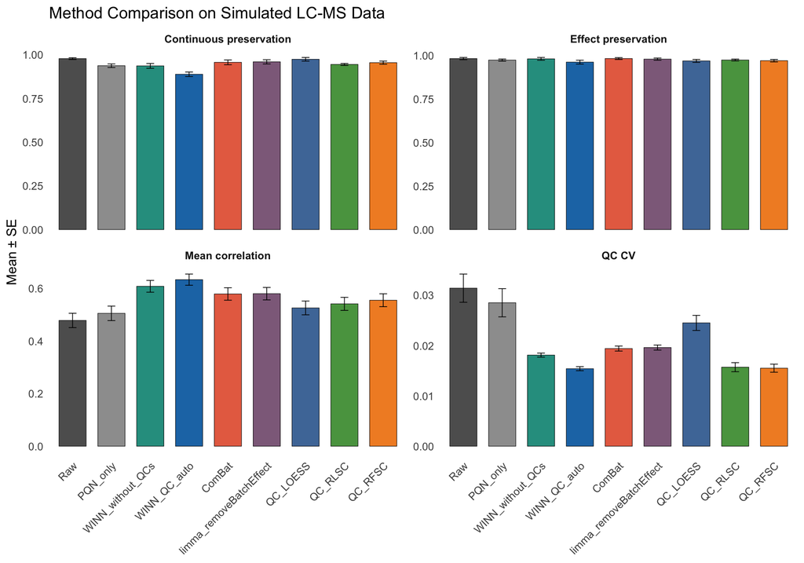

```r
if (!requireNamespace("ggplot2", quietly = TRUE)) stop("ggplot2 is required for plotting")
library(ggplot2)
# Add continuous covariate metrics to plot table
plot_rows <- summary_rows
plot_rows$method <- factor(plot_rows$method, levels = unique(plot_rows$method))

palette <- c(
  "Raw" = "#5E5E5E",
  "PQN_only" = "#9E9E9E",
  "WINN_without_QCs" = "#2A9D8F",
  "WINN_QC_auto" = "#1F77B4",
  "ComBat" = "#E76F51",
  "limma_removeBatchEffect" = "#8E6C8A",
  "QC_LOESS" = "#4E79A7",
  "QC_RLSC" = "#59A14F",
  "QC_RFSC" = "#F28E2B",
  "QC_RLSC_statTarget" = "#B07AA1",
  "SERRF" = "#EDC948"
)

ggplot(plot_rows, aes(x = method, y = mean, fill = method)) +
  geom_col(width = 0.7, color = "black", linewidth = 0.2) +
  geom_errorbar(aes(ymin = mean - se, ymax = mean + se),
                width = 0.2, linewidth = 0.3, na.rm = TRUE) +
  facet_wrap(~ metric, scales = "free_y") +
  scale_fill_manual(values = palette, drop = FALSE) +
  labs(
    title = "Method Comparison on Simulated LC-MS Data",
    x = NULL,
    y = "Mean ± SE"
  ) +
  theme_minimal(base_size = 12) +
  theme(
    panel.grid = element_blank(),
    legend.position = "none",
    axis.text.x = element_text(angle = 45, hjust = 1),
    strip.text = element_text(face = "bold")
  )
```